# Latent Variable GIMME

Z. F. Fisher & K. M. Gates

2019-05-17

## Introduction

This vignette will demonstrate the basic functionality available in latent variable gimme.

## Example Data

The example data contains multivariate time series data for 20 subjects in two subgroups. For each subject, 9 observed variable time series were generated based on 3 underlying latent time series. The data generating model for the first 10 subjects is given below under the heading Group 1 Model, and the second 10 subjects under the heading Group 2 model. For didactic purposes this data is homogenous at the individual level within each subgroup. This data is included in the `gimme` package and is labeled `simDataLV`.

### Preview Data for Subject 1

```r
head(round(gimme::simDataLV[[1]],2))
```

```
#>         V1    V2    V3    V4    V5    V6    V7    V8    V9
#> [1,]  1.07  0.12 -0.26 -1.17  0.64  1.47 -2.69 -0.50 -0.98
#> [2,]  0.37  0.99  1.27 -0.11  0.76 -0.34 -0.70  0.95 -1.70
#> [3,] -1.13  0.77 -0.26  0.89  0.06 -0.49  2.34  1.36 -0.46
#> [4,]  1.58 -1.89 -0.15 -1.04  0.75  0.34  0.87 -2.18  0.65
#> [5,]  2.32  1.42  2.10 -0.06 -1.36 -2.07 -1.27 -1.19 -0.62
#> [6,]  1.48  0.79  2.43  1.37 -0.21 -0.51 -0.03 -0.04 -0.64
```

### Group 1 Model (N=10)

[interactive chart not shown]

### Group 2 Model (N=10)

[interactive chart not shown]

## Specifying the Measurement Model

Latent variable GIMME requires a measurement model is specified in the `lv_model` argument. This measurement model should follow `lavaan` model syntax using the “=~” operator (read as “measured by”). For both groups described above the data generating model can be expressed as follows:

```r
lv_model_all <- '
  L1 =~ V1 + V2 + V3
  L2 =~ V4 + V5 + V6
  L3 =~ V7 + V8 + V9
'
```

### Individual-Specific Measurement Models

Latent variable GIMME also allows for individual-specific measurement models. In this case the object specificed in `lv_model` argument should be a list of length equal to the number of subjects in the analysis. We do not consider this option further here, however, if our analysis contained data from three individuals the list could be specified as follows:

```r
lv_model_ind1 <- '
  L1 =~ V1 + V2 + V3
  L2 =~ V4 + V5 + V6
  L3 =~ V7 + V8 + V9
'

lv_model_ind2 <- '
  L1 =~ V7 + V5 + V3
  L2 =~ V1 + V8 + V6
  L3 =~ V4 + V2 + V9
'

lv_model_ind3 <- '
  L1 =~ V4 + V2 + V9
  L2 =~ V1 + V5 + V3
  L3 =~ V7 + V8 + V6
'

lv_model_ind <- list(
  lv_model_ind1,
  lv_model_ind2,
  lv_model_ind3
)
```

## Latent Variable Estimator

The second argument required to run latent variable GIMME is `lv_estimator`. Currently, three options for `lv_estimator` exist, `miiv`, `pml`, and `svd`. If the `miiv` estimator is chosen the factor loadings for individual factor analysis models are estimated using MIIV-2SLS. In the case of the `pml` estimator, the factor loadings are estimated using the pseudo-ML estimator in `lavaan`. Finally, if `svd` is specified the first component for each set of indicators is obtained using singular value decomposition.

## Score Type

If the user specified `miiv` or `pml` for the `lv_estimator` option, two types of factor scores can be obtained, `bartlett` or `regression`. The default is `regression`. See the `lavaan` documentation for details on these factor score types.

## Final Model Estimator

The default estimator for the final models is the MIIV-2SLS estimator (`lv_final_estimator` = `miiv`). However, one can also estimate the final models using pseudo-ML (`lv_final_estimator` = `pml`).

```r
fit <- gimme::gimmeSEM(
  data = gimme::simDataLV,
  out="~/Desktop/out",
  subgroup = TRUE,
  lv_model = lv_model_all,
  lv_estimator = "miiv",
  lv_score = "regression",
  lv_final_estimator = "miiv"
)
```

[output not shown]

[output cut: 23 more lines]

```
#> individual-level search, subject 10 (subj10_grp1)
#> individual-level search, subject 11 (subj11_grp2)
#> individual-level search, subject 12 (subj12_grp2)
#> individual-level search, subject 13 (subj13_grp2)
#> individual-level search, subject 14 (subj14_grp2)
#> individual-level search, subject 15 (subj15_grp2)
#> individual-level search, subject 16 (subj16_grp2)
#> individual-level search, subject 17 (subj17_grp2)
#> individual-level search, subject 18 (subj18_grp2)
#> individual-level search, subject 19 (subj19_grp2)
#> individual-level search, subject 20 (subj20_grp2)
#> gimme finished running normally
#> output is stored in ~/Desktop/out
#> Number of subgroups = 2
#> Modularity = 0.45593
```

## Subgroup Recovery

The latent variable gimme algorithm correctly identifies the two subgroups as can be seen in the subgroup plots. Here the dashed lines indicate lagged effects.

### Subgroup 1

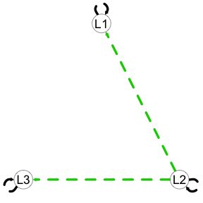

```r
 plot(qgraph::qgraph(fit$sub_plots[[1]]))
```

### Subgroup 2

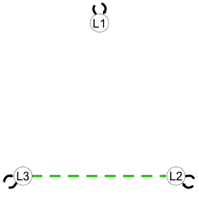

```r
 plot(qgraph::qgraph(fit$sub_plots[[2]]))
```

### MIIV Parameter Estimates

Furthermore, we can also examine the final MIIV estimates.

```r
fit$lvgimme$miiv_est_table
```

```
#>            subj   lhs op   rhs   est    se      z pvalue
#> 1    subj1_grp1    L1 =~    V1 1.000 0.000     NA     NA
#> 2    subj1_grp1    L1 =~    V2 1.030 0.048 21.458  0.000
#> 3    subj1_grp1    L1 =~    V3 1.003 0.047 21.269  0.000
#> 4    subj1_grp1 L1lag =~ V1lag 1.000 0.000     NA     NA
#> 5    subj1_grp1 L1lag =~ V2lag 1.030 0.048 21.458  0.000
#> 6    subj1_grp1 L1lag =~ V3lag 1.003 0.047 21.269  0.000
#> 7    subj1_grp1    L2 =~    V4 1.000 0.000     NA     NA
#> 8    subj1_grp1    L2 =~    V5 0.989 0.044 22.728  0.000
#> 9    subj1_grp1    L2 =~    V6 1.030 0.045 23.001  0.000
#> 10   subj1_grp1 L2lag =~ V4lag 1.000 0.000     NA     NA
#> 11   subj1_grp1 L2lag =~ V5lag 0.989 0.044 22.728  0.000
#> 12   subj1_grp1 L2lag =~ V6lag 1.030 0.045 23.001  0.000
#> 13   subj1_grp1    L3 =~    V7 1.000 0.000     NA     NA
#> 14   subj1_grp1    L3 =~    V8 0.967 0.045 21.493  0.000
```

[output cut: 436 more lines]